# PW2

2022-09-21

#Exemple 1

Question 1

```r
library(MASS)

dim(Boston)
```

```
## [1] 506  14
```

```r
summary(Boston)
```

```
##       crim                zn             indus            chas
##  Min.   : 0.00632   Min.   :  0.00   Min.   : 0.46   Min.   :0.00000
##  1st Qu.: 0.08205   1st Qu.:  0.00   1st Qu.: 5.19   1st Qu.:0.00000
##  Median : 0.25651   Median :  0.00   Median : 9.69   Median :0.00000
##  Mean   : 3.61352   Mean   : 11.36   Mean   :11.14   Mean   :0.06917
##  3rd Qu.: 3.67708   3rd Qu.: 12.50   3rd Qu.:18.10   3rd Qu.:0.00000
##  Max.   :88.97620   Max.   :100.00   Max.   :27.74   Max.   :1.00000
##       nox               rm             age              dis
##  Min.   :0.3850   Min.   :3.561   Min.   :  2.90   Min.   : 1.130
##  1st Qu.:0.4490   1st Qu.:5.886   1st Qu.: 45.02   1st Qu.: 2.100
##  Median :0.5380   Median :6.208   Median : 77.50   Median : 3.207
##  Mean   :0.5547   Mean   :6.285   Mean   : 68.57   Mean   : 3.795
##  3rd Qu.:0.6240   3rd Qu.:6.623   3rd Qu.: 94.08   3rd Qu.: 5.188
##  Max.   :0.8710   Max.   :8.780   Max.   :100.00   Max.   :12.127
##       rad              tax           ptratio          black
##  Min.   : 1.000   Min.   :187.0   Min.   :12.60   Min.   :  0.32
##  1st Qu.: 4.000   1st Qu.:279.0   1st Qu.:17.40   1st Qu.:375.38
##  Median : 5.000   Median :330.0   Median :19.05   Median :391.44
##  Mean   : 9.549   Mean   :408.2   Mean   :18.46   Mean   :356.67
##  3rd Qu.:24.000   3rd Qu.:666.0   3rd Qu.:20.20   3rd Qu.:396.23
##  Max.   :24.000   Max.   :711.0   Max.   :22.00   Max.   :396.90
##      lstat            medv
##  Min.   : 1.73   Min.   : 5.00
##  1st Qu.: 6.95   1st Qu.:17.02
##  Median :11.36   Median :21.20
##  Mean   :12.65   Mean   :22.53
##  3rd Qu.:16.95   3rd Qu.:25.00
##  Max.   :37.97   Max.   :50.00
```

```r
View(Boston)
```

Question 2

```r
train= 1:round(dim(Boston)[1]*0.8, digits=0)

test= -train

variables= c("lstat", "medv")

training_set= Boston[train, variables]

test_set= Boston[test, variables]

View(training_set)
View(test_set)
dim(training_set)
```

```
## [1] 405   2
```

Computes the 80% of the length of the Boston dataset and split it with this ratio (80% for train_set and 20% for the test_set)

Question 3

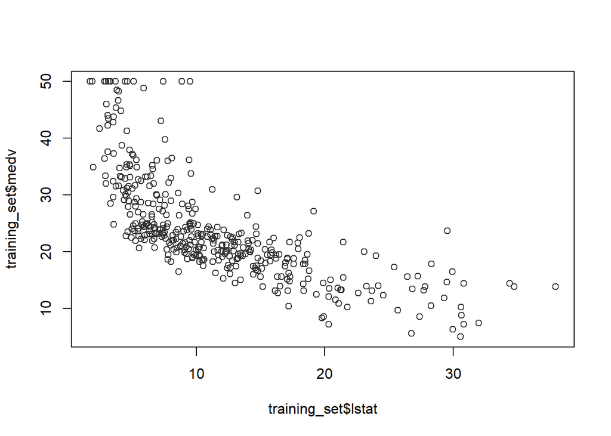

```r
plot(training_set$lstat, training_set$medv, col= "#333333")
```

We can see that there is no linearity between lstat and mdev

Question 4

```r
training_set$lstat= log(training_set$lstat)
```

Transforms the variable lsat into its computation of its logartithms

Question 5

```r
model <- lm(medv~log(lstat),data=training_set)
summary(model)
```

```
##
## Call:
## lm(formula = medv ~ log(lstat), data = training_set)
##
## Residuals:
##      Min       1Q   Median       3Q      Max
## -18.3322  -3.4016  -0.8448   2.2547  26.8080
##
## Coefficients:
##             Estimate Std. Error t value Pr(>|t|)
## (Intercept)  43.6437     0.7705   56.64   <2e-16 ***
## log(lstat)  -25.1588     0.9284  -27.10   <2e-16 ***
## ---
## Signif. codes:  0 '***' 0.001 '**' 0.01 '*' 0.05 '.' 0.1 ' ' 1
##
## Residual standard error: 5.532 on 403 degrees of freedom
## Multiple R-squared:  0.6457, Adjusted R-squared:  0.6448
## F-statistic: 734.4 on 1 and 403 DF,  p-value: < 2.2e-16
```

Question 6

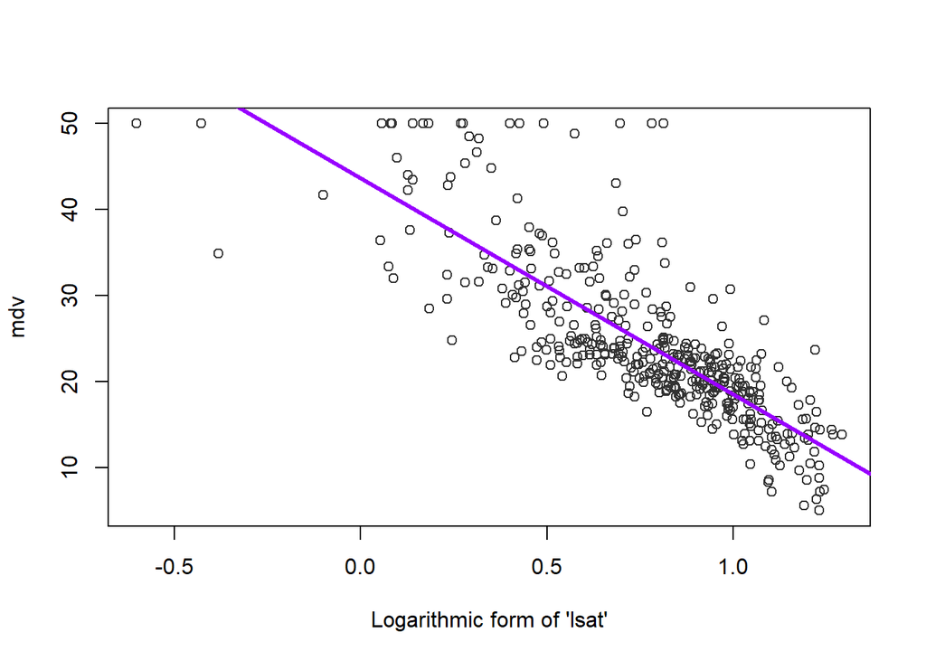

```r
plot(log(training_set$lstat), training_set$medv,
     xlab = "Logarithmic form of 'lsat'",
     ylab = "mdv",
     col= "#333333")

abline(model, col= "#9900FF", lwd =3)
```

We can see in grey the different points ploted before but with the logarithmic transformation and in purple the linear regression line

Question 7

```r
predict(model, data.frame(lstat = c(0.05)))
```

```
##        1
## 119.0128
```

Then the median value of the house with lsat=5% is $119.0128

Question 8

```r
predict(model, data.frame(lstat = c(0.05, 0.1, 0.15)))
```

```
##         1         2         3
## 119.01281 101.57405  91.37303
```

Then the median value of the house with: lsat=5% is $119.0128 lsat=10% is $101.57405 lsat=15% is $91.37303

Question 9

```r
train_model <- predict(model, data.frame(lstat = test_set$lstat))
train_MSE <- mean((test_set$medv - train_model)^2)
train_MSE
```

```
## [1] 1917.45
```

#Exemple 2